```python
%pylab inline
```

# Calentamiento Global?

```python
import csv
from scipy.interpolate import interp1d, splrep, splev

def print_interpolations(city):
    ff = open('temperaturas.csv', 'rt')
    reader = csv.reader(ff)

    dates = []
    hash_temperaturas = {}

    for row in reader:
        if row[4] == city and float(row[3]) != 999.9:
            date = datetime.datetime.strptime(row[5],"%Y-%m-%d")
            dates.append(date)
            hash_temperaturas[date] = float(row[3])

    dates = np.sort(dates)

    temperaturas = []
    for each in dates:
        temperaturas.append(hash_temperaturas[each])

    dates = matplotlib.dates.date2num(dates)

    max_date = datetime.datetime.strptime('2017-12-31',"%Y-%m-%d")
    max_date = matplotlib.dates.date2num(max_date)

    x_l = np.linspace(dates[0],max_date,10000)
    tck = splrep(dates, temperaturas, k=1)
    y_spl = splev(x_l, tck)

    regression = polyfit(dates, temperaturas, 1)
    y_reg = regression[0]*x_l + regression[1]

    figure(figsize=(8,6))
    plot_date(x_l, y_spl, '-b', c='k')
    plot_date(dates, temperaturas, 'o')
    title('Temperatura ' + city + ' - Interpolacion por splines')
    xlabel('Fecha')
    ylabel('Temperatura(ºC)')
    legend(['linear', 'data'])

    figure(figsize=(8,6))
    plot_date(x_l, y_reg, '-g', c='k')
    plot_date(dates, temperaturas, 'o')
    title('Temperatura ' + city + ' - Regresion lineal')
    xlabel('Fecha')
    ylabel('Temperatura(ºC)')
    legend(['linear', 'data'])

    print('Pendiente Regresion: ' + str(regression[0]))
```

## Bogota

```
Pendiente Regresion: 3.76907098385e-05
```

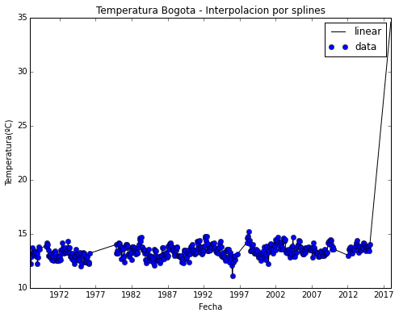

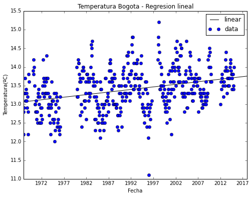

```python
print_interpolations('Bogota')
```

### Arriba podemos observar el analisis para Bogota. La extrapolacion a partir de los splines es un metodo sesgado pues depende completamente del ultimo polinomio que se use para construirla. Mientras tanto, la regresion lineal que se hace muestra una clara tendencia al alza, con una pendiente positiva!

## Barranquilla

```
Pendiente Regresion: 4.22214764236e-05
```

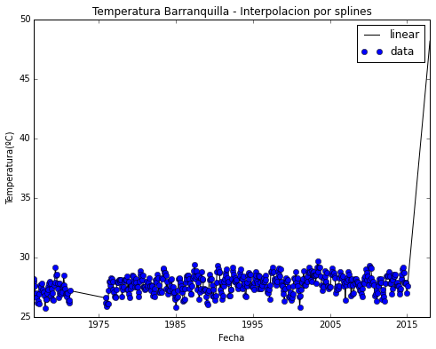

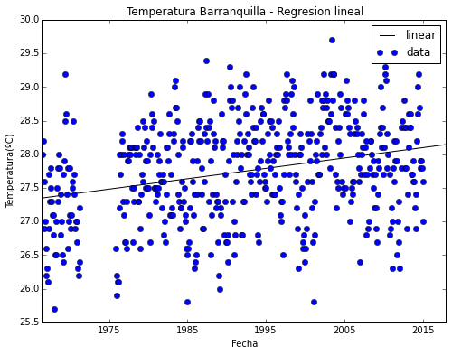

```python
print_interpolations('Barranquilla')
```

### El comportamiento es el mismo que se describio para los datos de Bogota. Es importante anotar que la pendiente es bastante pequeña, pero es que se obtiene en las unidades en que maneja numpy las fechas. La tendencia creciente es clara.

## Cali

```
Pendiente Regresion: 2.86918344257e-05
```

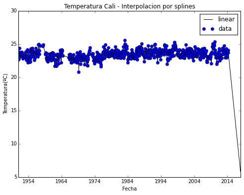

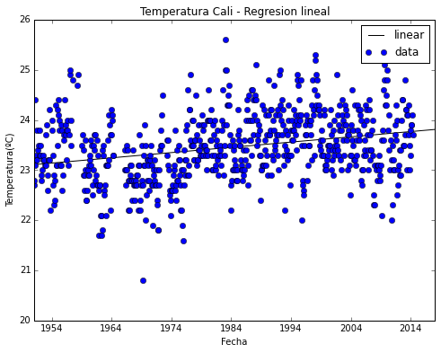

```python
print_interpolations('Cali')
```

### Vemos que la interpolacion por splines lleva a una extrapolacion que predice una caida en la temperatura de Cali para los proximos años. Esto es una evidencia que tal interpolacion es bastente dependiene de las condiciones de frontera al final del periodo. La pendiente de la regresion lineal sigue siendo positiva.

## Bucaramanga

```
Pendiente Regresion: 3.07961369132e-05
```

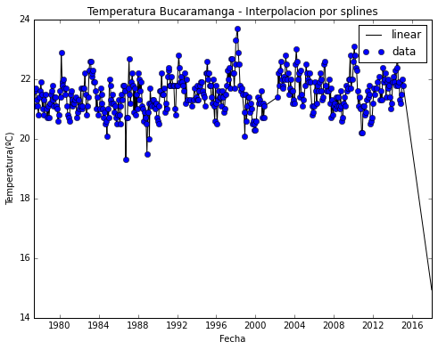

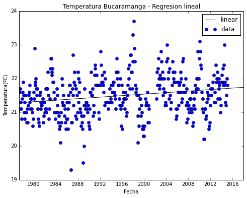

```python
print_interpolations('Bucaramanga')
```

### El mismo caso que con Cali. La prediccion por splines predice una era del hielo para el 2017, pero ya habiamos concluido que esta prediccion es errada. La tendencia lineal parece apuntar a un crecimiento en las temperaturas.

## Ipiales

```
Pendiente Regresion: 6.17049045719e-05
```

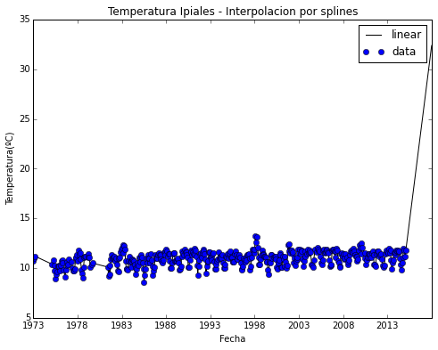

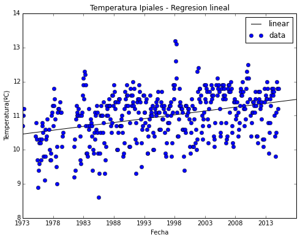

```python
print_interpolations('Ipiales')
```

### Finalmente, para la ciudad mas fria entre las estudiadas, encontramos la mayor pendiente para la regresion lineal. Las temperaturas parecen haber estado al alza (una vez mas).

## Conclusiones

### Antes de concluir, es importante anotar lo siguiente: No se encontro el R^2 para las anteriores regresiones pues evidentemente este dara bastante bajo. Esto pues la regresion se utilizo para descubrir una tendencia en los datos y no para ajustarlos a un modelo. El ajuste es evidentemente terrible en todos los casos. La tendencia, por otro lado, es clara: Las temperaturas han tendido al alza en los ultimos años. Es cierto que en el periodo de tiempo trabajado, todas las ciudades han experimentado epocas con temperaturas mas bajas de las habituales. Pero esto no significa que la tendencia estadistica este errada. No porque esta mañana haya hecho sol significa que Bogota es ahora un paraiso tropical. Hay un comportamiento marcado que apunta hacia un aumento de las temperaturas durante las ultimas decadas, asi la causa no sea posible hallarla con este analisis. El globo se calienta.